# Plant Hydraulic Transport

## Moving water through the plant is vital

- **Most transport materials dissolve in H<sub>2</sub>0**
- **Water is component of photosynthesis**
- **Water keeps cells turgid**
  - manipulated in guard cells
- **Water is weird and cool**
  - heavy
  - viscous (thick & *sticky*)

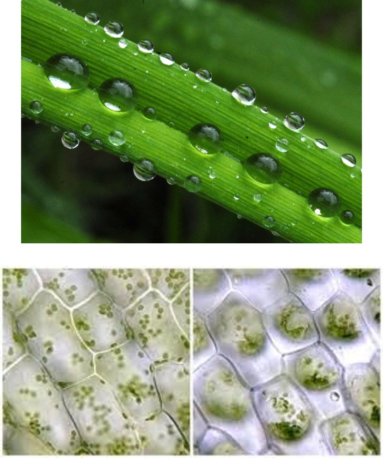

## Water has the capacity to do work: Water Potential

- **Water has free energy (chemical potential) = ability to do work or move**
  - in botany = water potential (\(\psi\))
  - \(\psi\) of pure water = 0 (no solutes)
  - \(\psi\) is generally negative but closer to 0 (higher) = more available energy
- **\(\psi\) determined by pressure, solutes & stickiness**
  - adding things to water (solutes) lowers water potential = -\(\psi\)
  - turgor in cells puts pressure on water (push) = higher \(\psi\)
  - tension on water in xylem (pull) = lower \(\psi\)
- **Movement of water is related to water potential**
  - water moves towards more negative \(\psi\) (more solutes)
  - cells interconnected = plant one big pond
  - \(\psi\) gradient drives water into roots, transport through xylem, and movement between cells

## Plant cell walls will never burst!

- **Example: Plant cells (-0.3 mPa \(\psi\)) placed in pure water**
  - water will move in to cell
- **In plant cells, pressure builds up as the central vacuole fills with water**
  - The rigid cell wall resists expansion, creating turgor pressure (positive \(\psi\)).
- **This pressure raises the overall water potential (Ψ), often offsetting negative Ψs from solutes**
  - without the balancing pressure, water flow into cells until the burst

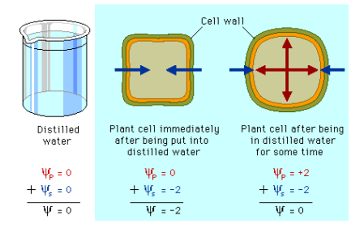

## Phloem: uses active transport & water potential

- **Source: sites where sugars are exported**
  - active leaves or storage tissues
- **Sinks: sites that receive phloem sap**
  - all parts of plant
- **Sugars actively loaded/unloaded into sieve elements**
  - at source and sink (often using ATP)
  - changes water potential (Ψ at both ends)
  - water diffuses in/out driving sap flow
  - phloem under high pressure

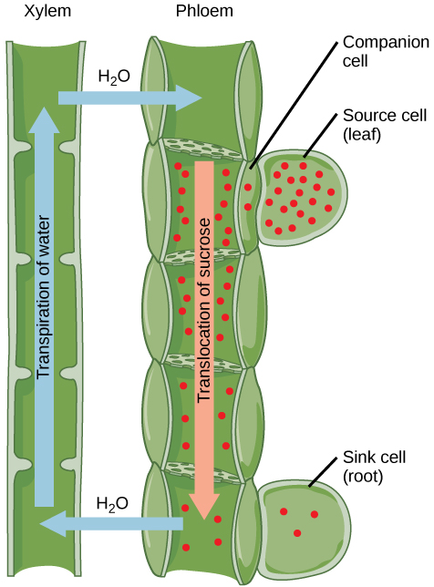

## Xylem Transport: Soil - Root - Stem - Leaf - **Air**

**Water potential gradients are the driving force of how water moves through a plant**

**Transpiration = loss of water through evaporation at the leaf surface**

**The atmosphere to which the leaf is exposed drives transpiration because air has a really negative Ψ**

**Creates a powerful negative pressure (tension) at the leaf surface, pulling water up**

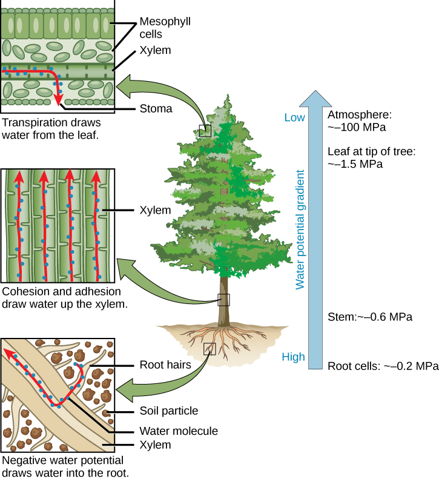

## Plant H<sub>2</sub>O transport: Soil - Root - Stem - Leaf - **Air**

**Air controls transpiration by changing the water potential difference between the leaf and atmosphere, essentially sucking water vapor out of the plant when stomata are open**

**Uptake: water moves towards more negative \(\psi\)**

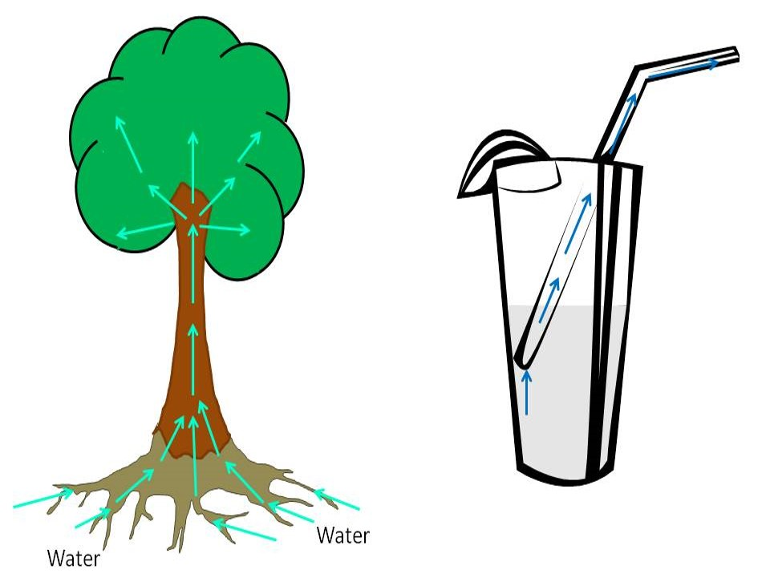

## Opening of stomata with sunlight creates the Ψ gradient

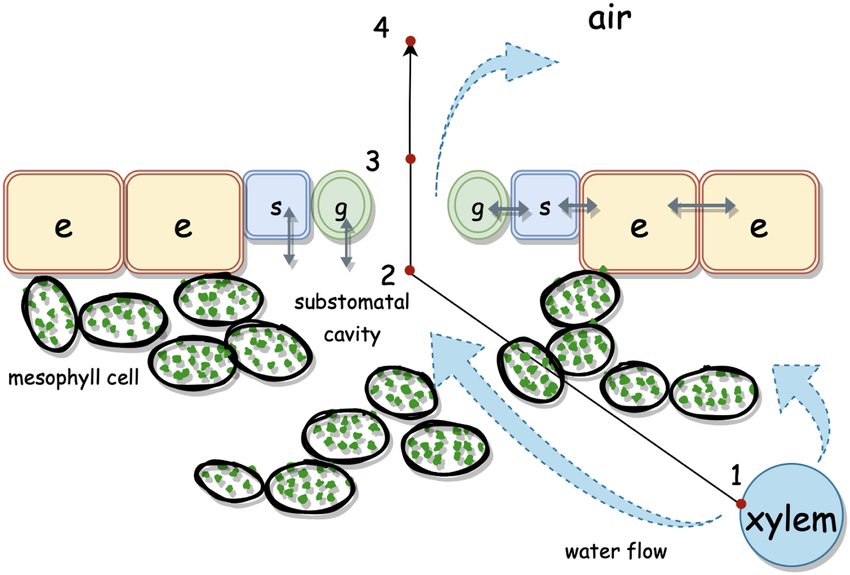

[figure not shown]

## Cohesion-tension: Capillary action aids upward movement

**Cohesion= water molecules sticking together via hydrogen bonding**

**Adhesion=water molecules sticking to the walls of xylem vessels**

**Combined create *capillary action (flow of liquid within narrow spaces)***

**Allows water to rise through the narrow tubes of the xylem, against the push of gravity, as an unbroken column**

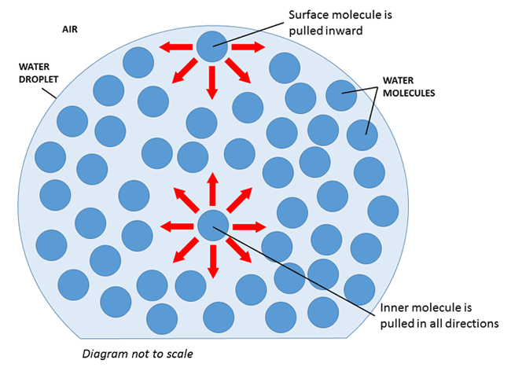

## Capillary action + transpiration move water through plant

**Evaporation of water at leaves creates the transpiration pull (gradient of negative \(\psi\))**

**This tension is transmitted down the whole water column due to cohesion**

**This stickiness of water keeps the column of water from pulling apart**

**When stomata are closed at night, cohesion/adhesion hold water in place**

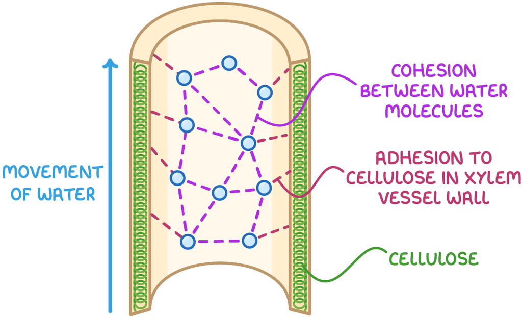

## Water pulled through root cells towards the xylem

**Pull of water under tension in vascular tissues means xylem have a more negative \(\psi\) than root cells**

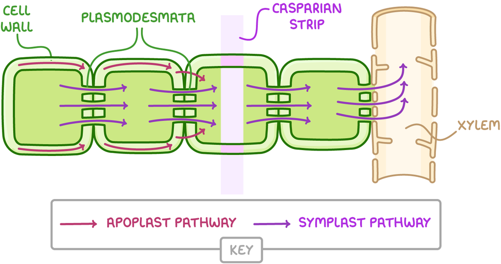

## Ψ gradient in roots cells drives osmosis

**Due to the \(\psi\) gradient in cells, the surrounding soil has a higher \(\psi\), driving diffusion into root hairs**

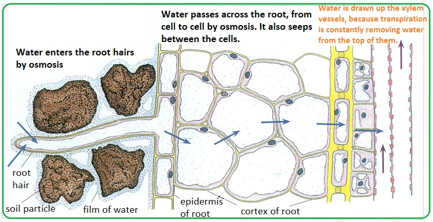

## Are there limits to moving water through plants?

[figure not shown]

- **Really large trees (redwoods) can move hundreds of gallons of water a day**
- **Gravity**
  - gets harder to move water vertically
  - xylem less efficient @ top
  - theoretically, limits growth to 122-130 m
- **Drying soil adds more tension**
  - \(\psi\) gets more negative, reducing the water potential gradient with the plant

## How can trees grow over 100 meters tall?

- **H<sub>2</sub>O also pulled in zig zag motion**
  - pits in vessels/tracheids
  - tracheids are twisted
- **Vascular tissue is tough**
  - high resistance of lignified walls
  - built not to collapse
- **Coastal redwood tree nears theoretical limit!**

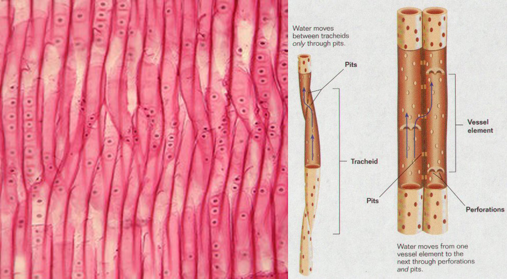

## Issue: When the column of water breaks, embolisms form

**Cavitation is the formation of air bubbles inside xylem vessels or tracheids, blocking water transport**  
**Occurs when tension (from transpiration pull) becomes too great, overpowering cohesion**

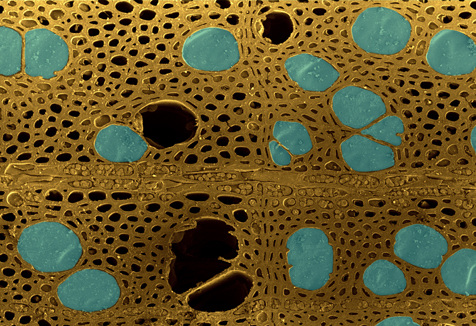

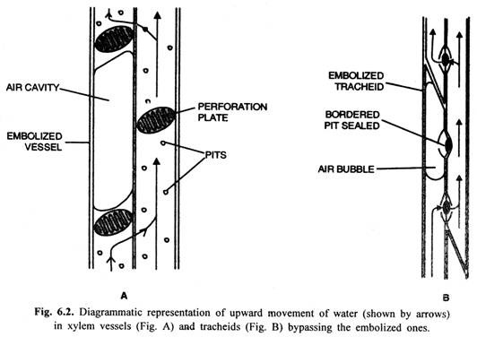

## The sound of water stress….

[video not shown]

## Fix: Can plants repair embolisms?

**A stem would need to create a new \(\psi\) with surrounding cells (via adding solutes) to refill while also compressing the air bubble until it dissolves into solution. If/how they do it is a huge matter of debate**

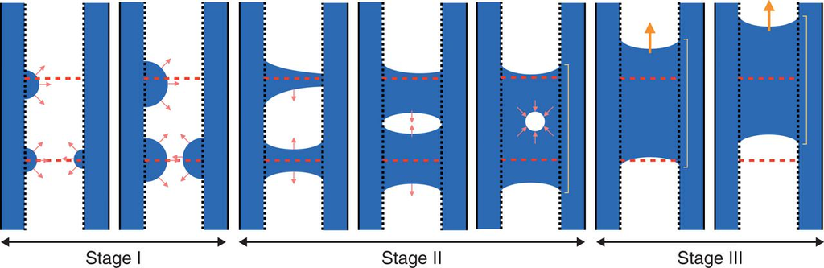

## Fix: Building new xylem cells works but slow and expensive

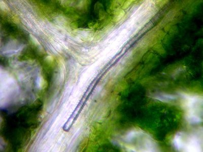

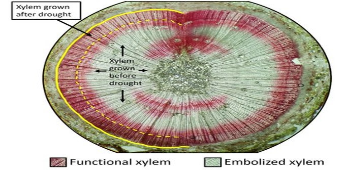

## Avoidance: Taper xylem (make skinny) as tree gets taller

**Decreasing xylem diameter as plant gets taller reduces cohesion tension and promotes adhesion**

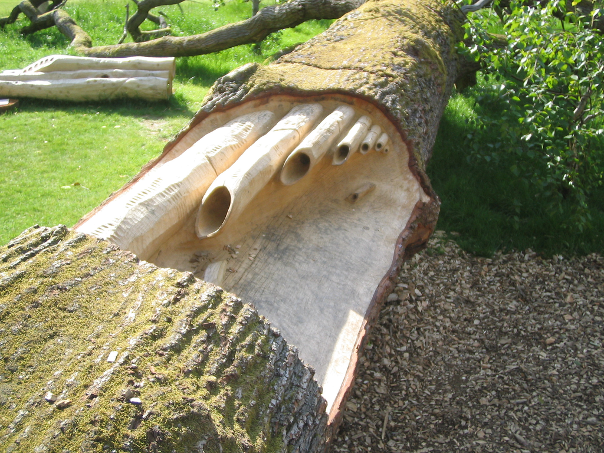

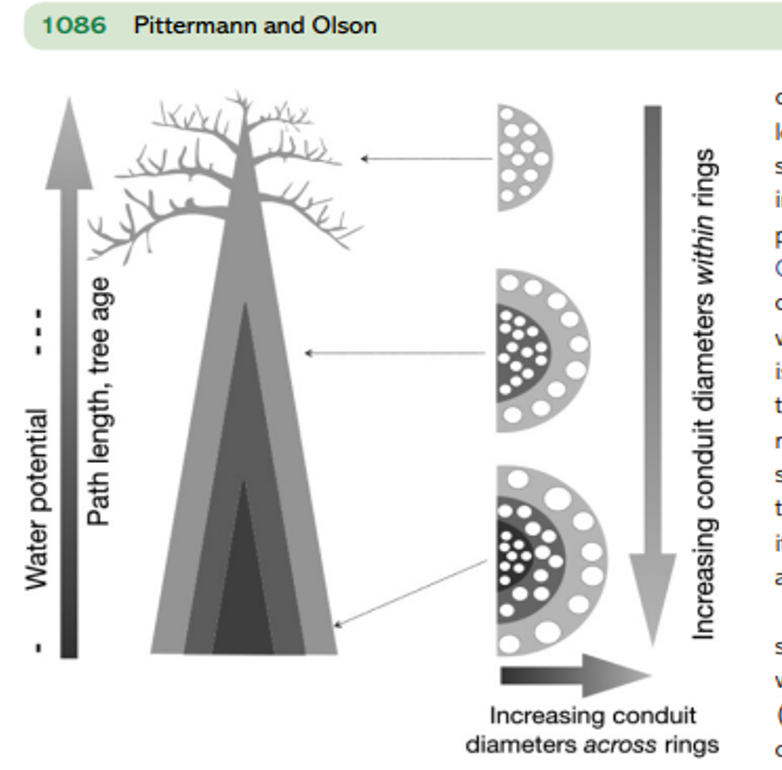

## Issues: Leaves (stomata) are sensitive to VPD

- **Vapor Pressure Deficit: difference between moisture in air and how much moisture air can hold**
  - if *high* then the air is ‘drier’
  - combo of temperature and humidity
- **High VPD creates massive pulling effect for transpiration**
- **If stressful, stomata *should* close**
  - stop excessive water loss

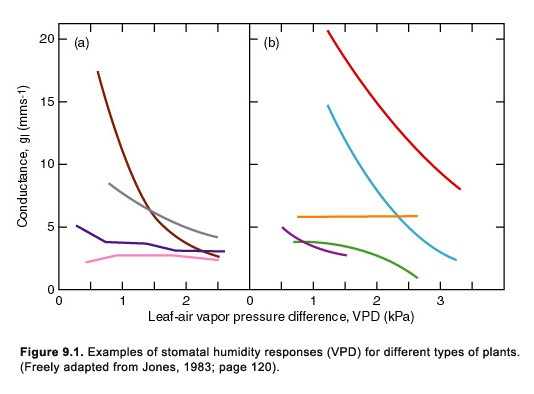

## FIX: Just close your stomata (Right?!?)

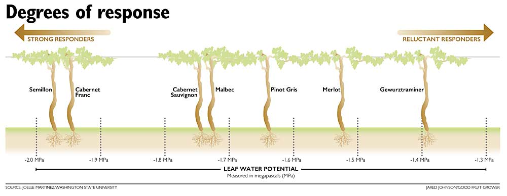

## Issue: What happens if if doesnt rain for a while?

- **If the soil dries out, what will ψ*soil* become?**
- **Generally, predawn ψ is really high**
  - right before sun comes up
  - stomata closed
- **During day: stomata open, air pulls and soil water drained**
  - ψ*soil* become?
- **How is this sustainable?**

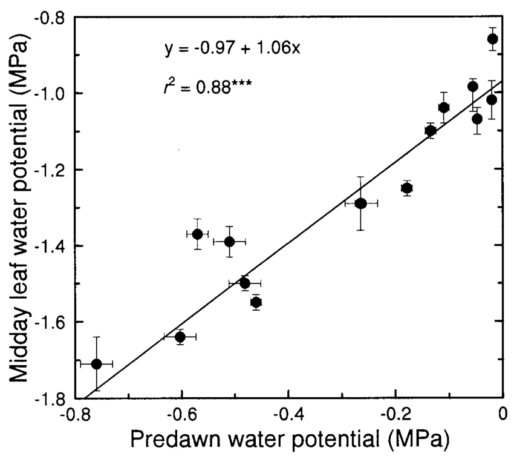

## Fix: Soils will refill without rain

- **Capillary action and surface attraction draw in water**
  - clay soils have lots of ‘pore’ space
  - often stronger than gravity
- **Potential energy (aka water potential) governs how water moves around in soil**
  - redistribution @ night
  - ‘sponge’ behavior during day
- **Prolonged drought can impact the soil water potentials**

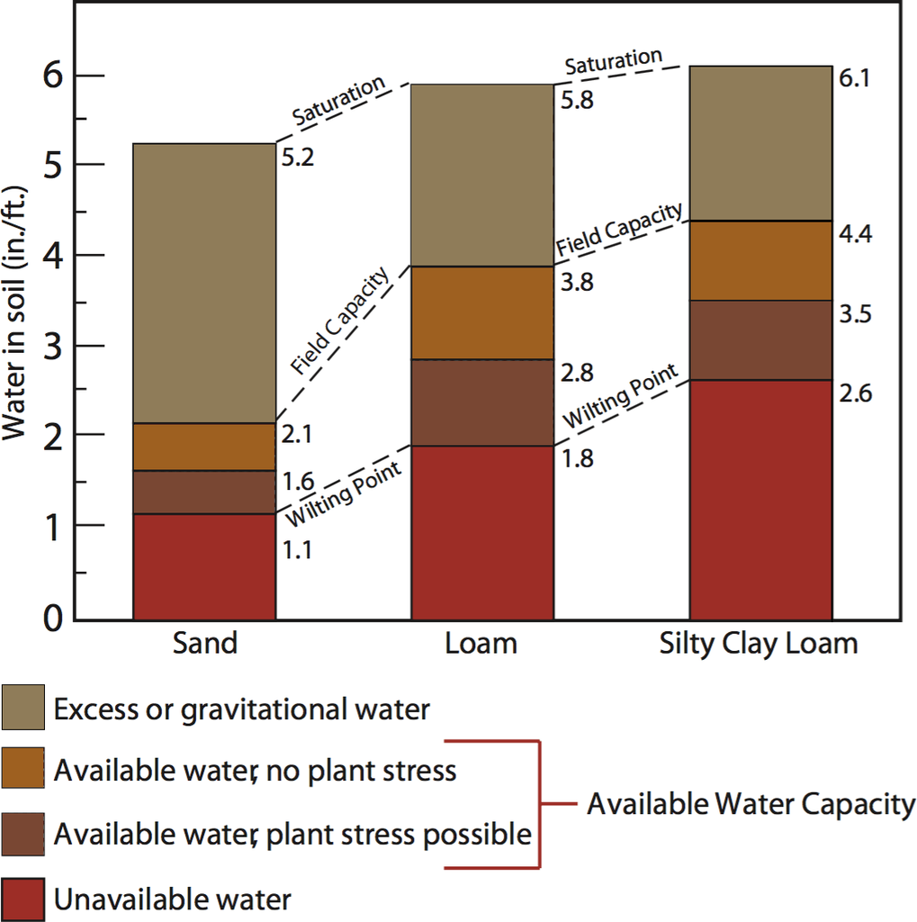

## Brainstorm: Will climate change impact plant water transport?

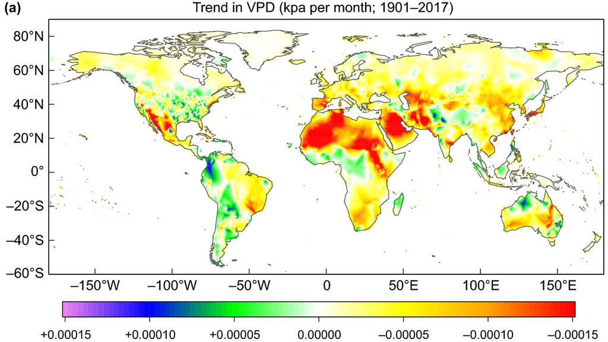